# Diamantes (Práctica AFI)

Gerardo Alcalá

## Análisis descriptivo: Dataset de diamantes.

El Dataset de diamantes se encuentra disponible en (http://ggplot2.tidyverse.org/reference/diamonds.html)[http://ggplot2.tidyverse.org/reference/diamonds.html] y está compuesto por 53,940 diamantes de los cuales se dispone de los siguientes atributos:

#### Lista de atributos del dataset.

- **Variables continuas:**
  - price
  - carat
  - depth
  - table
  - x
  - y
  - z
- **Variables categóricas:**
  - cut (ordinal)
  - color (ordinal)
  - clarity (ordinal)

### Análisis exploratorio de los datos.

Las variables categóricas de la base de datos tenemos tres ordinales. A continuación presentamos las tablas de frecuencias:

```r
kable(diamonds %>% group_by(cut) %>% summarise(Frecuencia=n(),Relativa=round(Frecuencia/nrow(diamonds)*100,2)))
```

| cut | Frecuencia | Relativa |
| --- | --- | --- |
| Fair | 1610 | 2.98 |
| Good | 4906 | 9.10 |
| Very Good | 12082 | 22.40 |
| Premium | 13791 | 25.57 |
| Ideal | 21551 | 39.95 |

```r
kable(diamonds %>% group_by(color) %>% summarise(Frecuencia=n(),Relativa=round(Frecuencia/nrow(diamonds)*100,2)))
```

| color | Frecuencia | Relativa |
| --- | --- | --- |
| D | 6775 | 12.56 |
| E | 9797 | 18.16 |
| F | 9542 | 17.69 |
| G | 11292 | 20.93 |
| H | 8304 | 15.39 |
| I | 5422 | 10.05 |
| J | 2808 | 5.21 |

```r
kable(diamonds %>% group_by(clarity) %>% summarise(Frecuencia=n(),Relativa=round(Frecuencia/nrow(diamonds)*100,2)))
```

| clarity | Frecuencia | Relativa |
| --- | --- | --- |
| I1 | 741 | 1.37 |
| SI2 | 9194 | 17.04 |
| SI1 | 13065 | 24.22 |
| VS2 | 12258 | 22.73 |
| VS1 | 8171 | 15.15 |
| VVS2 | 5066 | 9.39 |
| VVS1 | 3655 | 6.78 |
| IF | 1790 | 3.32 |

Si observamos los cortes, apenas el 12% de los diamantes tienen un corte *Fair* o *Good*, lo que deja al 88% de los diamantes con cortes *Very Good* o superiores.  
La distribución de colores es más uniforme salvo por el color *J* que sólo representa el 5% de los diamantes. Por último, la claridad de los diamantes de la base de datos concentra más de la mitad en los niveles *SI2*, *SI1* y *VS2* (63%), con muy pocos diamantes del nivel mínimo *I1* (1.3% solamente).

Gráficamente se pueden apreciar las frecuencias por atributo de cada variable, todas comparadas en la misma escala:

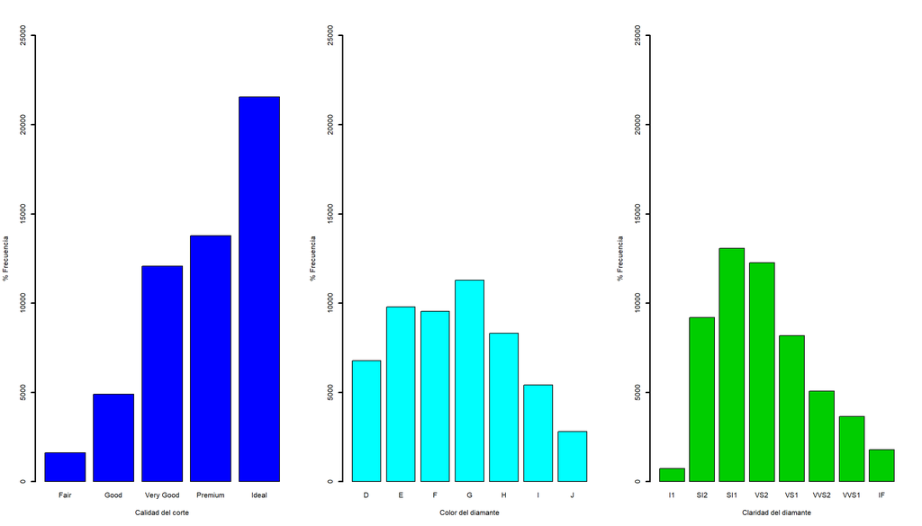

```r
par(mfrow=c(1,3))
barplot(table(diamonds$cut),xlab="Calidad del corte",
        ylab="% Frecuencia",col = 484,lwd = 2,cex.names =1,
        cex.axis = 1, ylim=c(0,25000))

barplot(table(diamonds$color),xlab="Color del diamante",
        ylab="% Frecuencia",col = 621,lwd = 2,cex.names =1,
        cex.axis = 1, ylim=c(0,25000))

barplot(table(diamonds$clarity),xlab="Claridad del diamante",
        ylab="% Frecuencia",col = 123,lwd = 2,cex.names =1,
        cex.axis = 1, ylim=c(0,25000))
```

En lo que respecta a las variables continuas, nos vamos a enfocar en la relación que tienen las variables *price*, *depth* y *carat* porque *depth* es una función de las variables *x*,*y*,*z* y *table*.

Los estadísticos más relevantes de cada variable son:

```r
kable(diamonds %>% summarise(media = round(mean(price),2),
                       min = round(min(price),2),
                       p25 = round(quantile(price,.25),2),
                       mediana = round(median(price),2),
                       p75 = round(quantile(price,.75),2),
                       max = round(max(price),2),
                       recorrido = max - min,
                       RI = p75 - p25,
                       Desv.Est = round(sd(price),2),
                       CV = round(Desv.Est/abs(media),2),
                       Simetría = round(skewness(price),2),
                       Curtosis = round(kurtosis(price),2)),align="cccccccccccc",caption="Estadísticas descriptivas de la variable _Price_")
```

Estadísticas descriptivas de la variable *Price*

| media | min | p25 | mediana | p75 | max | recorrido | RI | Desv.Est | CV | Simetría | Curtosis |
| --- | --- | --- | --- | --- | --- | --- | --- | --- | --- | --- | --- |
| 3932.8 | 326 | 950 | 2401 | 5324.25 | 18823 | 18497 | 4374.25 | 3989.44 | 1.01 | 1.62 | 5.18 |

```r
kable(diamonds %>% summarise(media = round(mean(carat),2),
                       min = round(min(carat),2),
                       p25 = round(quantile(carat,.25),2),
                       mediana = round(median(carat),2),
                       p75 = round(quantile(carat,.75),2),
                       max = round(max(carat),2),
                       recorrido = max - min,
                       RI = p75 - p25,
                       Desv.Est = round(sd(carat),2),
                       CV = round(Desv.Est/abs(media),2),
                       Simetría = round(skewness(carat),2),
                       Curtosis = round(kurtosis(carat),2)),align="cccccccccccc",caption="Estadísticas descriptivas de la variable _Carat_")
```

Estadísticas descriptivas de la variable *Carat*

| media | min | p25 | mediana | p75 | max | recorrido | RI | Desv.Est | CV | Simetría | Curtosis |
| --- | --- | --- | --- | --- | --- | --- | --- | --- | --- | --- | --- |
| 0.8 | 0.2 | 0.4 | 0.7 | 1.04 | 5.01 | 4.81 | 0.64 | 0.47 | 0.59 | 1.12 | 4.26 |

```r
kable(diamonds %>% summarise(media = round(mean(depth),2),
                       min = round(min(depth),2),
                       p25 = round(quantile(depth,.25),2),
                       mediana = round(median(depth),2),
                       p75 = round(quantile(depth,.75),2),
                       max = round(max(depth),2),
                       recorrido = max - min,
                       RI = p75 - p25,
                       Desv.Est = round(sd(depth),2),
                       CV = round(Desv.Est/abs(media),2),
                       Simetría = round(skewness(depth),2),
                       Curtosis = round(kurtosis(depth),2)),align="cccccccccccc",caption="Estadísticas descriptivas de la variable _Depth_")
```

Estadísticas descriptivas de la variable *Depth*

| media | min | p25 | mediana | p75 | max | recorrido | RI | Desv.Est | CV | Simetría | Curtosis |
| --- | --- | --- | --- | --- | --- | --- | --- | --- | --- | --- | --- |
| 61.75 | 43 | 61 | 61.8 | 62.5 | 79 | 36 | 1.5 | 1.43 | 0.02 | -0.08 | 8.74 |

Donde p25 y p75 con los percentiles 25 y 75 de la distribución, RI es el Rango Intercuartílico y CV es el Coeficiente de Variación.

Si nos enfocamos en las formas de la distribución de cada variable, podemos observar que la variable *price* es la que tiene mayor variabilidad (por tener un Coeficiente de Variación más grande), la variable *depth* es la más simétrica (Coeficiente de simetría cercano a 0) pero es la que tiene colas más pesadas (Curtosis de 8.74).

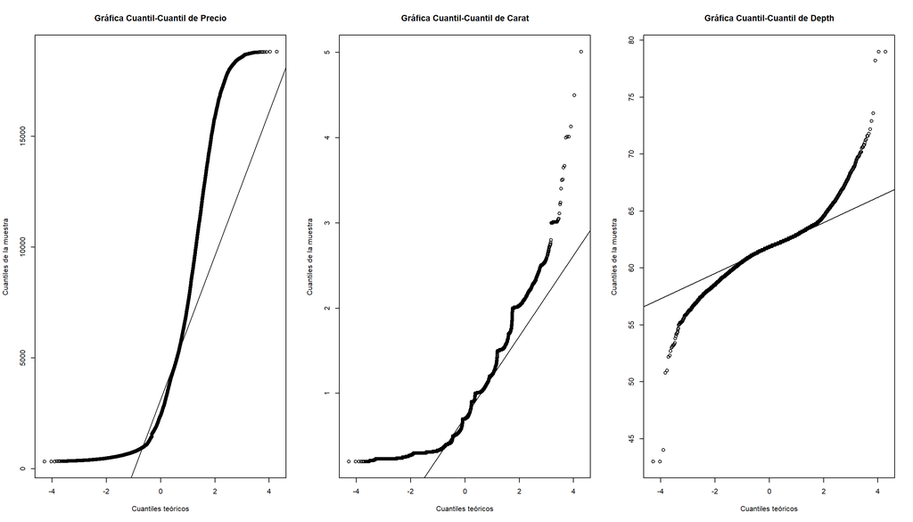

```r
par(mfrow=c(1,3))
qqnorm((diamonds$price),main="Gráfica Cuantil-Cuantil de Precio",xlab="Cuantiles teóricos",ylab="Cuantiles de la muestra")
qqline((diamonds$price))
qqnorm((diamonds$carat),main="Gráfica Cuantil-Cuantil de Carat",xlab="Cuantiles teóricos",ylab="Cuantiles de la muestra")
qqline((diamonds$carat))
qqnorm((diamonds$depth),main="Gráfica Cuantil-Cuantil de Depth",xlab="Cuantiles teóricos",ylab="Cuantiles de la muestra")
qqline((diamonds$depth))
```

De las gráficas cuantil-cuantil podemos concluir que las variables no siguen una distribución Normal y refuerza lo que habíamos observado con los estadísticos de momentos que hicimos anteriormente (en particular, las colas pesadas de la distribución de la variable *Depth*).

Ahora grafiquemos los histogramas, manteniendo la frecuencia en la misma escala para comparar la altura de las gráficas.

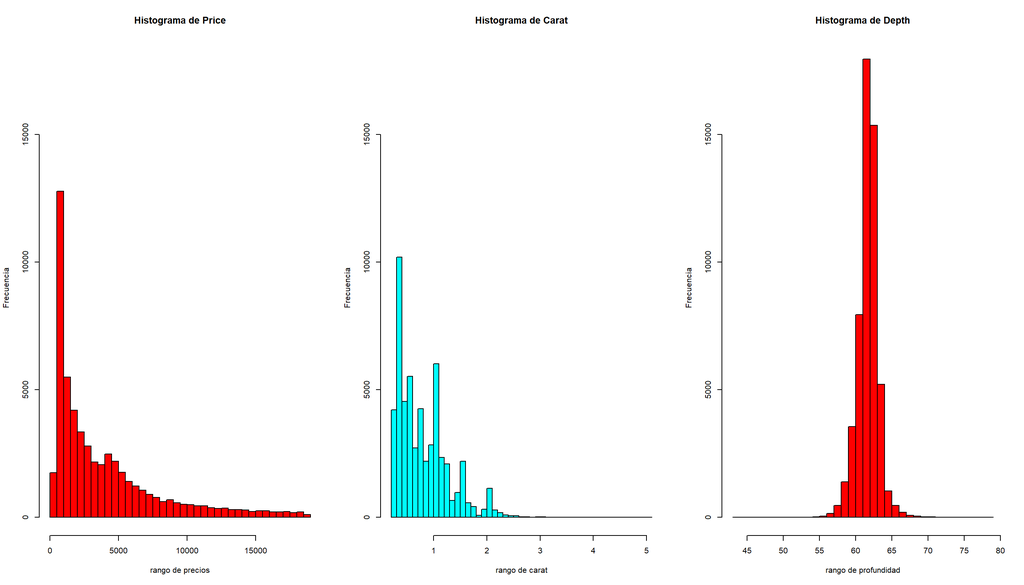

```r
par(mfrow=c(1,3))
hist(diamonds$price, col="red", main="Histograma de Price",freq=T,ylim=c(0,18000),breaks=40, xlab="rango de precios",ylab="Frecuencia")

hist(diamonds$carat, col=981, main="Histograma de Carat",freq=T,ylim=c(0,18000),breaks=40, xlab="rango de carat",ylab="Frecuencia")
hist(diamonds$depth, col =354, main="Histograma de Depth",freq=T,ylim=c(0,18000),breaks=40,xlab="rango de profundidad",ylab="Frecuencia")
```

También graficamos los histogramas de frecuencia relativa y ajustamos la densidad normal (teórica) para observar si siguen una distribución gaussiana o no.

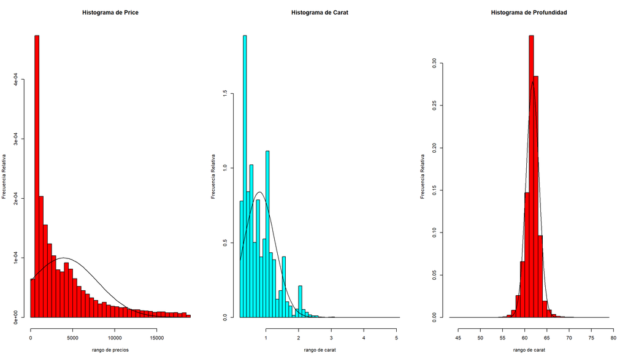

```r
par(mfrow=c(1,3))
hist(diamonds$price, col="red", main="Histograma de Price",freq=F,breaks=40, xlab="rango de precios",ylab="Frecuencia Relativa")
curve(dnorm(x, mean=mean(diamonds$price), sd=sd(diamonds$price)), add=TRUE)
hist(diamonds$carat, col=981, main="Histograma de Carat",freq=F,breaks=40, xlab="rango de carat",ylab="Frecuencia Relativa")
curve(dnorm(x, mean=mean(diamonds$carat), sd=sd(diamonds$carat)), add=TRUE)
hist(diamonds$depth, col =354, main="Histograma de Profundidad",freq=F,breaks=40,xlab="rango de carat",ylab="Frecuencia Relativa")
curve(dnorm(x, mean=mean(diamonds$depth), sd=sd(diamonds$depth)), add=TRUE)
```

Se observa que ninguna de las variables se ajusta bien a la densidad de una distribución normal, aunque la variable *depth* tiene una forma similar pero más punteaguda y con colas más pesadas (por las estadísticas descriptivas) lo que podría aproximarse a través de una *t-student*.

### Relación entre variables.

Para estudiar la relación que existe entre las variables primero exploraremos los diagramas de dispersión de las variables continuas:

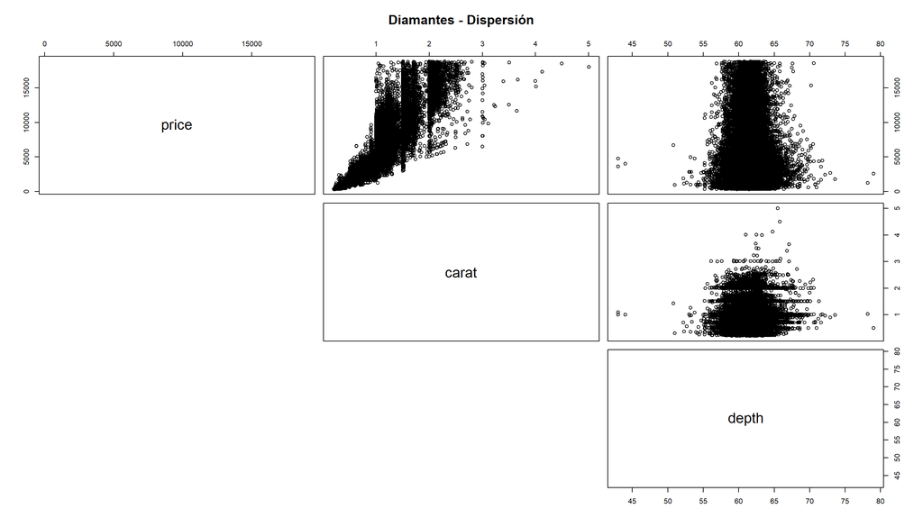

```r
pairs(diamonds[,c("price","carat","depth")],main = "Diamantes - Dispersión",
      pch = 21,col="black", lower.panel = NULL)
```

De las gráficas de dispersión se observa una relación entre el precio del diamante y el carat; mientras que las variables precio y profundidad no muestran una relación tan clara, como tampoco lo hacen las variables profundidad y carat. Si calculamos las correlaciones corroboramos lo antes dicho: la correlación entre precio y carat es de 0.92 mientras que las demás es muy cercana a 0.

```r
kable(round(cor(diamonds[,c("price","carat","depth")]),2),caption="Correlación de Pearson para variables continuas")
```

Correlación de Pearson para variables continuas

|  | price | carat | depth |
| --- | --- | --- | --- |
| price | 1.00 | 0.92 | -0.01 |
| carat | 0.92 | 1.00 | 0.03 |
| depth | -0.01 | 0.03 | 1.00 |

En lo que respecta a las variables categóricas podemos calcular la correlación de *spearman* para conocer si existe alguna relación entre ellas.

```r
var1 <- cbind(as.numeric(diamonds$cut),as.numeric(diamonds$clarity),as.numeric(diamonds$color))
colnames(var1) <- c("cut","clarity","color")
kable(round(cor(x=var1,method="spearman"),2),caption="Correlación de Spearman para variables categóricas")
```

Correlación de Spearman para variables categóricas

|  | cut | clarity | color |
| --- | --- | --- | --- |
| cut | 1.00 | 0.19 | -0.02 |
| clarity | 0.19 | 1.00 | 0.03 |
| color | -0.02 | 0.03 | 1.00 |

De la tabla anterior se desprende que hay una asociación positiva entre el corte (*cut*) y la claridad del diamante (*clarity*), mientras que el color no correla tanto con las otras variables.

Si queremos calcular la correlaciòn de variables continuas y categóricas primero debemos agrupar las variables continuas. Haremos 9 grupos de las variables continuas y calcularemos la correlación de *spearman*.

```r
price_g <- cut2(diamonds$price,g=9)
carat_g <- cut2(diamonds$carat,g=9)
depth_g <- cut2(diamonds$depth,g=9)
var1 <- cbind(as.numeric(diamonds$cut),as.numeric(diamonds$clarity),as.numeric(diamonds$color),
              price_g,carat_g,depth_g)
colnames(var1) <- c("cut","clarity","color","price","carat","depth")
kable(round(cor(x=var1,method="spearman"),2),caption="Correlación de Spearman para variables categóricas y continuas discretizadas")
```

Correlación de Spearman para variables categóricas y continuas discretizadas

|  | cut | clarity | color | price | carat | depth |
| --- | --- | --- | --- | --- | --- | --- |
| cut | 1.00 | 0.19 | -0.02 | -0.10 | -0.14 | -0.20 |
| clarity | 0.19 | 1.00 | 0.03 | -0.21 | -0.37 | -0.07 |
| color | -0.02 | 0.03 | 1.00 | 0.15 | 0.25 | 0.05 |
| price | -0.10 | -0.21 | 0.15 | 1.00 | 0.95 | 0.01 |
| carat | -0.14 | -0.37 | 0.25 | 0.95 | 1.00 | 0.03 |
| depth | -0.20 | -0.07 | 0.05 | 0.01 | 0.03 | 1.00 |

Esto nos permite identificar correlaciones positivas entre precio y color y negativas entre precio y las variables corte y claridad (interesante y ligeramente contraintuitivo).

Hay distintas formas de analizar si una variable categórica tiene relación con las variables continuas, a continuación exploraremos algunas alternativas y propondremos relaciones.

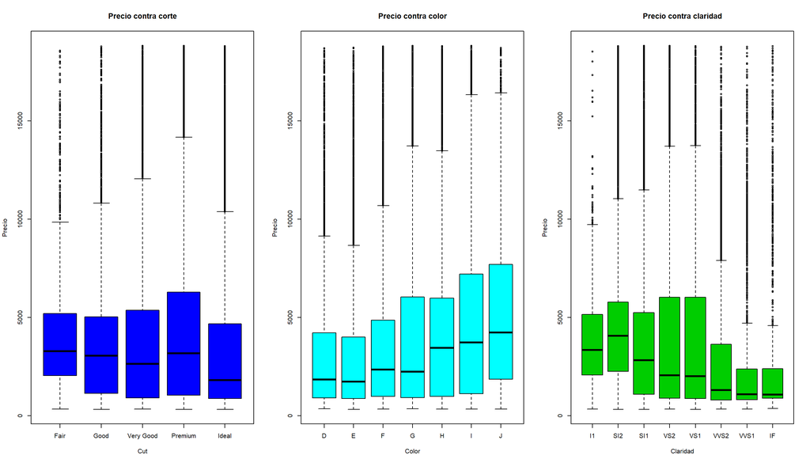

```r
par(mfrow=c(1,3))
boxplot(price ~ cut,data=diamonds,main="Precio contra corte",ylab="Precio",xlab="Cut",col=484)
boxplot(price ~ color,data=diamonds,main="Precio contra color",ylab="Precio",xlab="Color",col=621)
boxplot(price ~ clarity,data=diamonds,main="Precio contra claridad",ylab="Precio",xlab="Claridad",col=123)
```

De las gráficas anteriores se observan una gran cantidad de *outliers* para la variable precio, por lo que es conveniente seguir explorando las relaciones con otras visualizaciones.

```r
print("Densidad del precio por cada grupo de Corte")
```

```
## [1] "Densidad del precio por cada grupo de Corte"
```

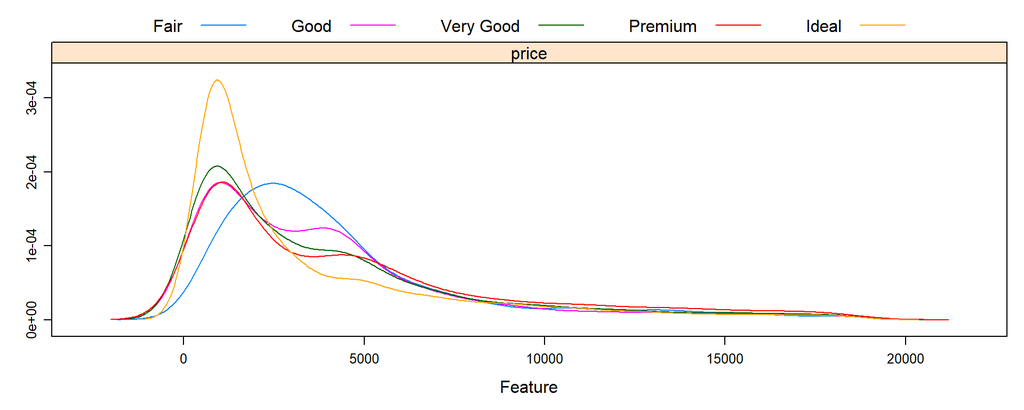

```r
featurePlot(x = diamonds[, c("price")],
            y = diamonds$cut,
            plot = "density",
            ## Pass in options to xyplot() to
            ## make it prettier
            scales = list(x = list(relation="free"),
                          y = list(relation="free")),
            adjust = 1.5,
            pch = "",
            layout = c(1, 1),
            auto.key = list(columns = 5))
```

```r
print("Densidad del precio por cada grupo de Color")
```

```
## [1] "Densidad del precio por cada grupo de Color"
```

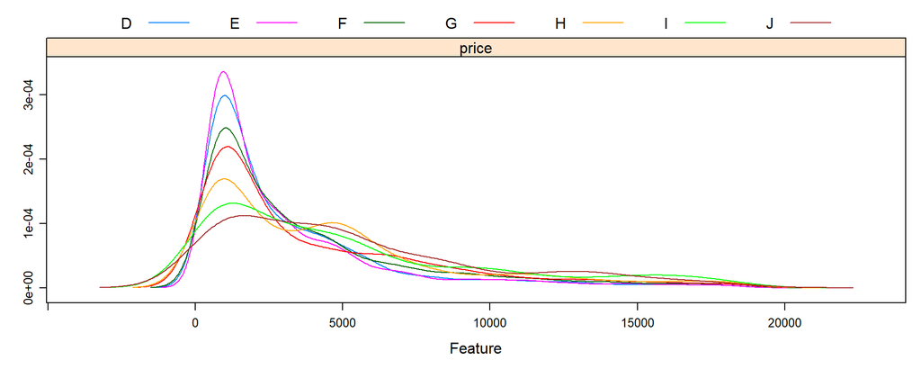

```r
featurePlot(x = diamonds[, c("price")],
            y = diamonds$color,
            plot = "density",
            ## Pass in options to xyplot() to
            ## make it prettier
            scales = list(x = list(relation="free"),
                          y = list(relation="free")),
            adjust = 1.5,
            pch = "",
            layout = c(1, 1),
            auto.key = list(columns = 7))
```

```r
print("Densidad del precio por cada grupo de Claridad")
```

```
## [1] "Densidad del precio por cada grupo de Claridad"
```

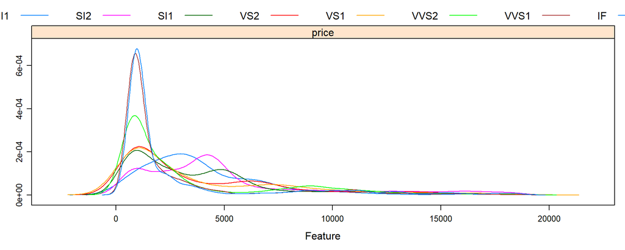

```r
featurePlot(x = diamonds[, c("price")],
            y = diamonds$clarity,
            plot = "density",
            ## Pass in options to xyplot() to
            ## make it prettier
            scales = list(x = list(relation="free"),
                          y = list(relation="free")),
            adjust = 1.5,
            pch = "",
            layout = c(1, 1),
            auto.key = list(columns = 8))
```

Nuevamente nos damos algunas ideas de las relaciones pero seguimos sin ser capaces de concluir mucho con las gráficas solamente, por lo que debemos realizar algunas pruebas estadísticas para contrastar hipótesis. Veamos primero las medias del precio agrupadas por cada una de las variables categóricas.

```r
kable(diamonds %>%
  group_by(cut) %>%
  summarise(cuenta = n(),
            precio_medio = round(mean(price),2),
            predio_mediana = round(median(price),2),
            sd_precio = round(sd(price),2),
            min_precio = round(min(price),2),
            max = round(max(price),2)
            ),
  caption = "Estadísticas de precio por grupo de Corte")
```

Estadísticas de precio por grupo de Corte

| cut | cuenta | precio_medio | predio_mediana | sd_precio | min_precio | max |
| --- | --- | --- | --- | --- | --- | --- |
| Fair | 1610 | 4358.76 | 3282.0 | 3560.39 | 337 | 18574 |
| Good | 4906 | 3928.86 | 3050.5 | 3681.59 | 327 | 18788 |
| Very Good | 12082 | 3981.76 | 2648.0 | 3935.86 | 336 | 18818 |
| Premium | 13791 | 4584.26 | 3185.0 | 4349.20 | 326 | 18823 |
| Ideal | 21551 | 3457.54 | 1810.0 | 3808.40 | 326 | 18806 |

```r
kable(diamonds %>%
  group_by(color) %>%
  summarise(cuenta = n(),
            precio_medio = round(mean(price),2),
            predio_mediana = round(median(price),2),
            sd_precio = round(sd(price),2),
            min_precio = round(min(price),2),
            max = round(max(price),2)
            ),
  caption = "Estadísticas de precio por grupo de Color")
```

Estadísticas de precio por grupo de Color

| color | cuenta | precio_medio | predio_mediana | sd_precio | min_precio | max |
| --- | --- | --- | --- | --- | --- | --- |
| D | 6775 | 3169.95 | 1838.0 | 3356.59 | 357 | 18693 |
| E | 9797 | 3076.75 | 1739.0 | 3344.16 | 326 | 18731 |
| F | 9542 | 3724.89 | 2343.5 | 3784.99 | 342 | 18791 |
| G | 11292 | 3999.14 | 2242.0 | 4051.10 | 354 | 18818 |
| H | 8304 | 4486.67 | 3460.0 | 4215.94 | 337 | 18803 |
| I | 5422 | 5091.87 | 3730.0 | 4722.39 | 334 | 18823 |
| J | 2808 | 5323.82 | 4234.0 | 4438.19 | 335 | 18710 |

```r
kable(diamonds %>%
  group_by(clarity) %>%
  summarise(cuenta = n(),
            precio_medio = round(mean(price),2),
            predio_mediana = round(median(price),2),
            sd_precio = round(sd(price),2),
            min_precio = round(min(price),2),
            max = round(max(price),2)
            ),
  caption = "Estadísticas de precio por grupo de Claridad")
```

Estadísticas de precio por grupo de Claridad

| clarity | cuenta | precio_medio | predio_mediana | sd_precio | min_precio | max |
| --- | --- | --- | --- | --- | --- | --- |
| I1 | 741 | 3924.17 | 3344 | 2806.78 | 345 | 18531 |
| SI2 | 9194 | 5063.03 | 4072 | 4260.46 | 326 | 18804 |
| SI1 | 13065 | 3996.00 | 2822 | 3799.48 | 326 | 18818 |
| VS2 | 12258 | 3924.99 | 2054 | 4042.30 | 334 | 18823 |
| VS1 | 8171 | 3839.46 | 2005 | 4011.75 | 327 | 18795 |
| VVS2 | 5066 | 3283.74 | 1311 | 3821.65 | 336 | 18768 |
| VVS1 | 3655 | 2523.11 | 1093 | 3334.84 | 336 | 18777 |
| IF | 1790 | 2864.84 | 1080 | 3920.25 | 369 | 18806 |

De las tablas anteriores parece que Color tiene una relación más fuerte con precio (pues la media, a excepción del primer nivel, crece conforme mejoramos el color del diamante), mientras que el corte y la claridad no parecen tener una relación tan directa. En particular, el Corte *Fair* tiene un precio promedio mayor al Corte *Good*, veamos is esto es estadísticamente significativo:

**NOTA:** Si somos rigurosos, la prueba que debemos realizar dado que los datos no se distribuyen normal (lo vimos por la curtosis y el coeficiente de asimetría) es contrastar el estadístico con una distribución Normal, sin embargo, podemos utilizar la prueba $t$ dado que los grados de libertad que tendrán nuestros estadísticos $t$ aproximarán bastante a la Normal.

```r
cut_fair <- diamonds$price[diamonds$cut=="Fair"]
cut_good <- diamonds$price[diamonds$cut=="Good"]
t.test(cut_fair,cut_good, var.equal=FALSE, paired=FALSE,alternative="g",conf.level=.95)
```

```
##
##  Welch Two Sample t-test
##
## data:  cut_fair and cut_good
## t = 4.1684, df = 2822.3, p-value = 1.58e-05
## alternative hypothesis: true difference in means is greater than 0
## 95 percent confidence interval:
##  260.2001      Inf
## sample estimates:
## mean of x mean of y
##  4358.758  3928.864
```

Por lo que rechazamos la hipótesis nula $\mu_{fair} < \mu_{good}$, así que la diferencia en medias es estadísticamente significativa.  
También podemos probar si la claridad *IF* tiene un mayor precio en promedio que los diamantes de claridad *VVS1*.

```r
clar_IF <- diamonds$price[diamonds$clarity=="IF"]
clar_VVS1 <- diamonds$price[diamonds$clarity=="VVS1"]
t.test(clar_IF,clar_VVS1, var.equal=FALSE, paired=FALSE,alternative="g",conf.level=.95)
```

```
##
##  Welch Two Sample t-test
##
## data:  clar_IF and clar_VVS1
## t = 3.169, df = 3091.6, p-value = 0.0007724
## alternative hypothesis: true difference in means is greater than 0
## 95 percent confidence interval:
##  164.2985      Inf
## sample estimates:
## mean of x mean of y
##  2864.839  2523.115
```

Nuevamente rechazamos la hipótesis nula, que esta ves es $\mu_{IF} < \mu_{VVS1}$, así que estadísticamente podemos concluir que el precio promedio de los diamantes con claridad *IF* es mayor que el de los diamantes con claridad *VVS1*.

También comparamos la media del carat para los cortes *Fair* y *Good*, pero en este caso queremos comprobar si $H_0: \mu_{fair} = \mu_{good}$:

```r
cut_fair <- diamonds$carat[diamonds$cut=="Fair"]
cut_good <- diamonds$carat[diamonds$cut=="Good"]
t.test(cut_fair,cut_good, var.equal=FALSE, paired=FALSE,conf.level=.95)
```

```
##
##  Welch Two Sample t-test
##
## data:  cut_fair and cut_good
## t = 13.667, df = 2476.7, p-value < 2.2e-16
## alternative hypothesis: true difference in means is not equal to 0
## 95 percent confidence interval:
##  0.1686944 0.2252096
## sample estimates:
## mean of x mean of y
## 1.0461366 0.8491847
```

Podemos concluir entonces que las medias no son iguales con un *p-value* de prácticamente 0.

### Conclusiones

Después de revisar la base de datos podemos concluir que existe una fuerte asociación lineal entre la variable *price* y la variable *carat*, por lo que podríamos proponer que para explicar el precio de un diamante la variable más importante sí es su quilataje, sin embargo, no es la única variable que influye y la relación que tiene con las categorías de *color*, *cut* y *clarity* también es importante. Después de explorar las relaciones de todas las variables proponemos el siguiente cuadro que visualiza la mayor interacción de variables en un gráfico que al principio parece muy saturado pero da mucho sentido:

El scatterplot de *price* contra *carat* es obvio por ser las variables que presentan mayor asociación lineal. Las dimensiones de *cut* y *clarity* nos permiten comparar las densidades de estas dos variables (en los extremos hay menor cantidad de puntos, lo que explica porqué hay menos diamantes de baja claridad y buen corte o muy pocos diamantes de corte “Fair” y claridad *IF*), esto es un primer *insight* que nos da mayor entendimiento de los datos. La otra relación que es evidente es la relación entre las variables *color* y *carat*: los diamantes de mayor *carat* tienen mejor color. Si observamos todos los diagramas de dispersión, el color *Excelente* que agrupa los niveles *I* y *J* esta generalmente por arriba y el grupo *Medio* que agrupa *D*, *E* y *F* está por abajo. También se aprecia que, para un mismo corte (es decir, por columna), los diamantes tienen mayor claridad conforme decrece el *carat* (esto es, las gráficas van *aplastándose* cuando ves las columnas de arriba a abajo) y la relación del corte con el precio, para un mismo nivel de claridad (viendo filas de izquierda a derecha) en general aumenta cuando ves la densidad de puntos que incrementa a la derecha del gráfico.

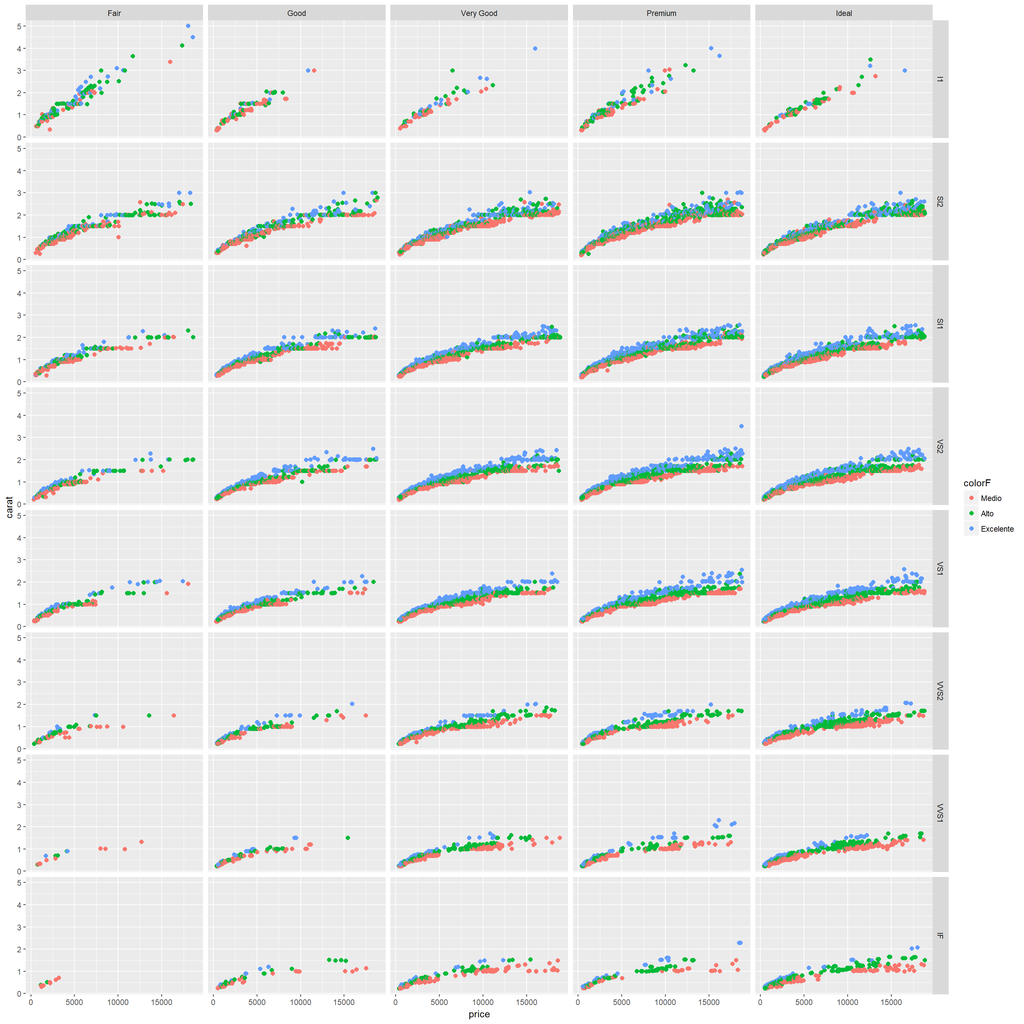

```r
diamonds %>% mutate(colorF = factor(ifelse(color %in% c("D","E","F"),"Medio",ifelse(color %in% c("G","H"),"Alto","Excelente")),levels = c("Medio","Alto","Excelente"),ordered=T)) %>%
  ggplot(aes(x = price, y = carat, color = colorF)) +
  geom_point(size = 2) +
  facet_grid(clarity ~ cut)
```